# Skills Required for Sports Analytics

UWAGGS

# Prelude

Sports analytics jobs are increasing in popularity but have quickly become over-saturated with talented and passionate individuals. In a sector where supply out-paces demand, how can we ensure that we are competitive candidates? In this presentation we will survey the sports analytics job landscape and see what we can do to best prepare ourselves!

# Recent Postings

Let’s look at the following job postings. Are there any things that are in common or distinct between them? Here we are focusing on intern roles, so things may be different for full time and more senior positions.

- [Strategy and Analytics / Research and Development](https://jobs.dayforcehcm.com/en-US/onesse/CANDIDATEPORTAL/jobs/862)
- [Data Science](https://www.driblab.com/job-opening/job-opening-data-science-intern/)
- [Data Engineer / Systems Architecture](https://ats.rippling.com/en-CA/teamworks-careers/jobs/6425a2c9-5f2d-4600-a456-de4858b5f8f8)
- [Machine Learning Engineer](https://ats.rippling.com/en-CA/teamworks-careers/jobs/787d6180-28bc-43c5-843f-239bbf1c110c)
- [Biomechanics](https://recruitingbypaycor.com/career/JobIntroduction.action?clientId=8a7883d08b729b3e018b72dc67f6007f&id=8a78839f91e3131c01921ff4fb366af4&source=&lang=en)
- [Sport Science](https://recruitingbypaycor.com/career/JobIntroduction.action?clientId=8a7883d08b729b3e018b72dc67f6007f&id=8a78839f91e3131c01921ff592bd6b23&source=&lang=en)

# Follow up Questions - Group Discussion

From these example job descriptions:

- What are typical job responsibilities?
- What skills are required?
- What academic backgrounds are typically desired?

# Next Steps:

Q. How can we use data science to perform this analysis at scale?

A. **Text mining**!

- Text mining is the process of analyzing unstructured data such as text. Such data can be found in speeches, web pages, and in our case, job descriptions.
- Applications of text mining include natural language processing and sentiment analysis, where we analyze a set of documents to draw meaning and patterns from the text.
- Tools to perform analysis on text data include word clouds, frequency counts (eg TF-IDF), and similarity indices (eg Jaccard).
- The following resources are great places to begin to learn more about text mining:
  - [An Introduction to Data Science](https://www.amazon.ca/INTRODUCTION-DATA-SCIENC-Jeffrey-Saltz/dp/150637753X), Chapters 14 & 15 (Saltz & Stanton)
  - [Text Mining With R: A Tidy Approach](https://www.tidytextmining.com) (Silge & Robinson)

# Case Study: General Data Science Positions

- The following procedure was completed for general data science jobs in 2018.
  - Approximately 7000 jobs were scraped from Indeed and uploaded onto a [Kaggle dataset](https://www.kaggle.com/datasets/sl6149/data-scientist-job-market-in-the-us#alldata.csv)
  - Job descriptions were *tokenized* and *stemmmed* to ensure that words were not double counted or missed due to varying endings
  - Here were their findings:
    - The top 5 tools: **Python**, **SQL**, **R**, Excel, and Scala.
    - The top 5 skills: **Machine Learning**, **Modeling**, **Optimization**, Data Visualization (go take Stat 442 in Winter 2025), and Artificial Intelligence
    - The most desired degree: Masters and PhD
    - The most desired major: Data Science, Statistics, Mathematics, and other majors related to **quantitative fields**.
- A [paper](https://www.researchgate.net/publication/351614411_Demystifying_Job_Roles_in_Data_Science_A_Text_Mining_Approach) using a similar approach was published in 2021.
  - Here, they used the following workflow:

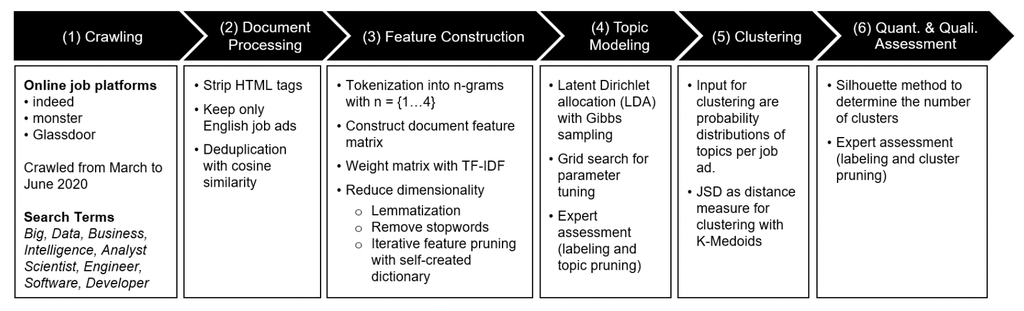

- Group discussion: What modifications would be necessary for sports analytics specific analysis?
  - Using [Teamworkonline](https://www.teamworkonline.com) and other more relevant sources

# Advice from Industry Leaders

“When I was a hiring manager in analytics for the Dodgers, we would post an entry-level quantitative analyst position and receive nearly a thousand applications. Among those candidates, based on the application alone, roughly half would seem to be qualified for the entry-level position. Without the resources to interview 500 candidates, we had to decide which small subset of candidates would advance to the interview stage (this is its own challenge and a story for another day).

I relay this experience to you because it conveys some perspective from the other side of the job application process. How will you separate yourself (before the interview stage) from the many other candidates who could be qualified for the position? The best way to make your resume rise to the top of the stack is to **work on a research project and present it at a sport analytics conference**. If a resume reviewer is already familiar with your work (assuming it’s good work) before seeing your name in the candidate pool, then they are much more likely to offer you an interview.”

# “-work on a research project and present it at a sport analytics conference”

How does UWAGGS support students to be able to work on projects and present them at conferences?

- **[Collaboration Board](https://docs.google.com/document/d/1AWtAKGFowSwDV_gPKn48oTrHHS0lzZ3z3W3tCTuxx68/edit?usp=sharing)**: Our internal collaboration board is purposed to facilitate collaboration between students who would like to work on projects. Put your contact info, project type, and ideas and form connections with students who have interesting ideas!
- **[Conferences Document](https://docs.google.com/document/d/1AkYDp-m5Z0SmAECf4xLWJUAi0a2lqET_jXnZlmQtwC4/edit?usp=sharing)**: We have a shared document where we upload conference opportunities as well as additional information including abstract submission and registration deadlines.
- **Funding Opportunities**: We have started a thread in the [#conferences](https://discord.com/channels/1200538188784078958/1234121606721306634) channel of our Discord server with different sources of funding offered by departments at UW. Most are happy to cover a sizable portion of associated costs.

# How do we support technical skill acquisition at UWAGGS?

- The **[#resources](https://discord.com/channels/1200538188784078958/1253349106643111977)** channel in our Discord server is a great place to start, where members share items that they find useful.
- **[guideR](https://docs.google.com/spreadsheets/d/1LPe8xYduoep9qCrNzBGdJHaHZ8dnmdHNnu7UXZKzawU/edit?usp=sharing)**: guideR was created by Dominic Samangy, the Basketball Analytics Coordinator for the New Orleans Pelicans. In this document some excellent open-source work, coding tutorials, and overall learning materials are included, including guides for **four** analytical softwares; `R`, `Python`, `Tableau`, and `SQL`.
- Our bi-weekly sessions! Please direct topic requests to our email, in the discord, or to [our feedback form](https://docs.google.com/forms/d/e/1FAIpQLScn6QmYB1s5X3goN5RZYFtfKvMBFsvZ0_1rRCtM6OMLjtJxVQ/viewform).
  - For those who cannot make some sessions or joined the club late, we try to record all of our sessions and are in the process of uploading all of the code and supplementary materials from past sessions onto our [website](https://www.uwaggs.ca/sessions.html) and [GitHub repository](https://github.com/uwaggs/sessions).

# How has our club been doing?

- **[LINHAC 2024](https://www.ida.liu.se/research/sportsanalytics/LINHAC/LINHAC24/home.html)**: The Linköping Hockey Analytics Conference (LINHAC) aims to bring together professionals and academics with an interest in hockey analytics. The conference feature the latest research in hockey analytics in academia and companies, panel discussions with analysts, coaches, GMs and players, industry sessions with the latest hockey analytics products, and an analytics competition for students.
  - UWAGGS members **Ali-Raza Zaidi**, **Fauzan Lodhi**, **Sky Wu**, **Ryan Cao**, and **David Awosoga** were finalists for the student competition, with Ali, Fauzan, and Ryan travelling to Sweden to attend the conference! Their project can be found [HERE](https://github.com/AliRZ-02/linhac2024).
- **[CASSIS 2024](http://www.cascadiasports.com)**: The Cascadia Symposium on Statistics in Sports (CASSIS) is a meeting of statisticians and quantitative analysts connected with sports teams, sports media, and universities to discuss common problems of interest in statistical modeling and analysis of sports data. The symposium format is a mixture of invited talks, a poster session, and a panel discussion.
  - UWAGGS members **David Awosoga** and **Matthew Chow** presented their poster analyzing the career performance progression for Olympic track and field athletes. Their project can be found [HERE](https://github.com/awosoga/peaks-and-primes).
- **[CMSAC 2024](https://www.stat.cmu.edu/cmsac/conference/2024/)**: The Carnegie Mellon Sports Analytics Conference is an annual event dedicated to highlighting the latest sports research from the statistics and data science community.
  - UWAGGS members **Shamar Phillips** and **Rithika Silva** will be presenting a poster at this conference with their exceptional **[usportsR](https://uwaggs.github.io/usportsR/index.html)** and **usportspy** packages; open-source repositories enabling users to extract and analyze data from U SPORTS, the governing body of university sport in Canada. Their project writeup can be found [HERE](https://github.com/uwaggs/USPORTS-Packages-Paper).
- Internally, we encourage members to submit and view other projects on our **[Projects Document](https://docs.google.com/document/d/1iKoBHEqmhUdAQO1tqV7yC82_ecvYcBtVvS5864cAr6c/edit?usp=sharing)** by posting the links in the [#projects](https://discord.com/channels/1200538188784078958/1200546029276238058) channel of our club Discord server.
  - **Show and Tell**: We also dedicate a session in some terms for members to present on projects that they’re working on, no matter how big, small, polished, or unrefined they are. At our show and tell session in the Spring 2024 term we had 6 great presentations!

# On the horizon: Conferences

- **[SABR Analytics](https://sabr.org/analytics)**: The 2025 Society for American Baseball Research (SABR) Analytics Conference will be taking place from March 14-16, 2025 in Phoenix, Arizona. This conference brings together some of the brightest minds in the baseball analytics community to discuss, debate, and share insightful ways to analyze and examine baseball. Students receive a heavily discounted registration fee of $50 to join virtually or $150 in person, which, apart from admission to the general conference, includes an exceptional student-only session on March 13 and a one year SABR membership.
  - The deadline to [submit an abstract for a research presentation](https://sabr.org/latest/submit-your-presentation-abstract-for-2025-sabr-analytics-conference/) is **November 20, 2024**. There is both a general track and a student track.
- **[CSAS](https://statds.org/events/csas2025/index.html)**: The 2025 Connecticut Sports Analytics Symposium (CSAS) will be hosted at Yale University from April 11-12, 2025. This is a student-focused sports analytics conference aiming to showcase sports analytics to students at an accessible level, train students in data analytics with applications to sports data, and foster collaboration between academic programs and the sports industry
  - Abstracts submission will open in the new year and close in mid-March.

# On the horizon: Competitions

- **[BDB](https://operations.nfl.com/gameday/analytics/big-data-bowl/)**: The National Football League’s Big Data Bowl (BDB) is the largest sports analytics contest in the world, with $100,000 in total grand prizes and massive outreach for participants to receive hiring opportunities. The competition runs from mid-October to early January, and there are separate tracks for teams of university students and open professionals.
  - The competition is Kaggle-based and uses completely open-source, high quality tracking data. If you’re looking for a competition to get your feet wet in the analytics space, this is the one. The **[2025 competition](https://www.kaggle.com/competitions/nfl-big-data-bowl-2025)** was launched on October 10 and is focusing on predicting plays based on team formations. Sign up today!!
- **[CSAS](https://statds.org/events/csas2025/challenge.html)**: Alongside the conference component, this data challenge will focus on the recently released bat swing and swing length data released by the MLB from Baseball Savant. Teams can be up to 3 members, and the registration deadline is December 1.
- **[MSLE x UTSPAN Data Challenge](https://www.linkedin.com/posts/university-of-toronto-sports-analytics-student-group_this-fall-term-we-are-partnering-with-the-activity-7233845408441978880-Natt/?utm_source=share&utm_medium=member_ios)**: All students across Ontario universities are invited to work on a project using SPL’s cutting-edge basketball data. SPL staff will lead supplementary seminars and workshops. Select student submissions will have the opportunity to be presented in front of MLSE staff and compete for prizes! Interested students can fill out this [data challenge interest form](https://docs.google.com/forms/d/1xu0_TC9ko-InDZ5FA3TmKIIMbRkTz1ZPY0rTMrVBObc/viewform?edit_requested=true) and join their club discord for more information. If you have any questions, feel free to reach out. Competition runs until early November.

# Conclusion

Hopefully you now have a better idea of what skills are necessary to be successful in sports analytics. A follow up session will involve a more comprehensive study of available positions using the text mining principles discussed here. If there are any gaps between what we’ve identified and what we support as a club, please let us know!! We are committed to assistant you with however far you want to take your sports analytics journey.